# Modeling Report

Daniel J Eck

In this report, we examine additional modeling considerations for era-adjusted baseball statistics. These considerations arise from an effort to better contextualize Babe Ruth’s home run production, particularly during his transformation into the “Sultan of Swat” in 1919–1920.

## Park Factors

We initially applied handedness-specific park factors following Michael Schell’s implementation in *Baseball’s All-Time Best Sluggers (2005)*. While these adjustments are useful once home run hitting becomes a stable offensive strategy, they produce highly unstable results in the immediate post-1919 period.

The table below shows Babe Ruth’s 1919–1921 seasons, where HR denotes park-adjusted home runs and obs_HR denotes actual home runs. The adjustment introduces substantial volatility, adding 12 home runs in 1919 and subtracting 14 in both 1920 and 1921.

```
##        name yearID       HR obs_HR
## 1 Babe Ruth   1919 41.68151     29
## 2 Babe Ruth   1920 39.65711     54
## 3 Babe Ruth   1921 45.47196     59
```

Below we see that total home runs begin to stabilize above 1000 after 1928 (with the exception of the WAR depleted 1943 season).

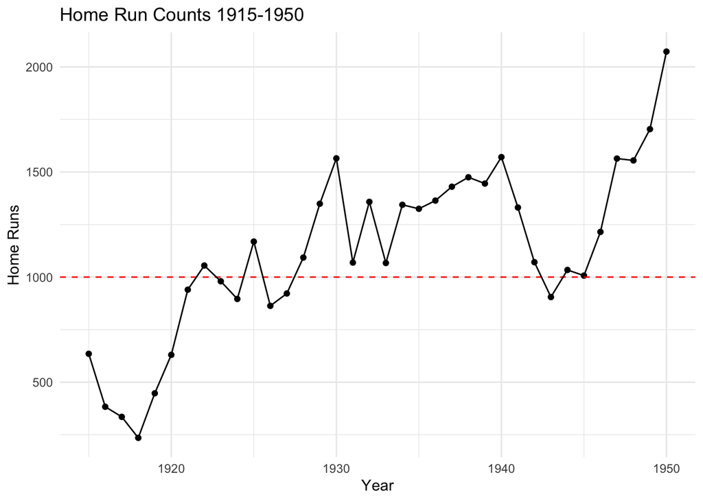

We therefore apply handedness-specific park factors beginning in 1928. Over this period, the adjusted results for Babe Ruth exhibit substantially greater stability.

```
##        name yearID        HR obs_HR
## 1 Babe Ruth   1928 48.868909     54
## 2 Babe Ruth   1929 43.261625     46
## 3 Babe Ruth   1930 45.585463     49
## 4 Babe Ruth   1931 44.339237     46
## 5 Babe Ruth   1932 39.562037     41
## 6 Babe Ruth   1933 33.417119     34
## 7 Babe Ruth   1934 20.532311     22
## 8 Babe Ruth   1935  6.830541      6
```

## Tail Modeling

Here we examine key features of the tail probability modeling routine. The modeling operates on transformed pairs $(W,Y)$, where $W$ indexes tail position and $Y$ represents the corresponding transformed performance measure used for fitting.

The current implementation uses a robust approach that allows for more flexible (nonlinear) fitting, whereas the legacy implementation relies on a linear specification. The distinction between these approaches becomes especially pronounced in the presence of extreme observations.

In general, the robust method adapts to outliers by incorporating them into the fitted relationship, effectively compressing their apparent extremeness in the transformed (tail) space. By contrast, the legacy approach does not adjust as aggressively, preserving the visual and statistical prominence of extreme values.

To illustrate these differences, we compare both methods directly across selected seasons featuring historically large performances. All statistics are first transformed into shrinkage-based rate estimates (e.g., HR per AB), which shrink individual performance rates toward the league average within each season and stabilize variance across players. This transformation ensures that differences across seasons better reflect underlying performance rather than variation in opportunity or league context.

Here we compare the two tail probability models for select Babe Ruth and Barry Bonds home run seasons. In each case, the robust implementation is pulled toward the extreme observation, producing a smoother fit that makes the outlier appear less exceptional. The legacy method, by maintaining a linear fit, preserves the separation between the extreme point and the bulk of the data. As a result, the robust method effectively compresses historically extraordinary Ruth and Bonds seasons, placing them closer to the upper range of typical performance rather than as clear all-time outliers.

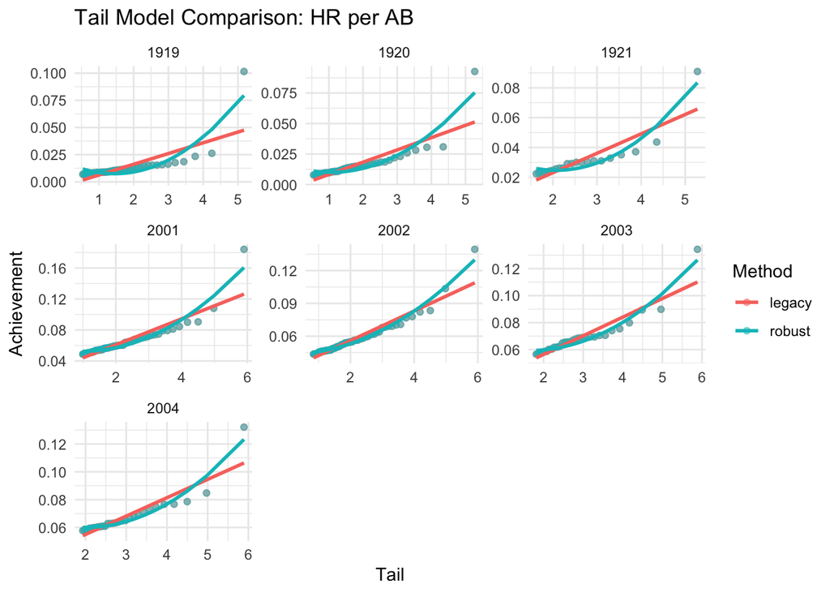

A similar pattern emerges when examining seasons in which Babe Ruth led Major League Baseball in rate-based bWAR. The robust method again adjusts toward the extreme performance, effectively compressing its apparent distinctiveness, while the legacy method maintains a clearer separation between the top season and the rest of the distribution.

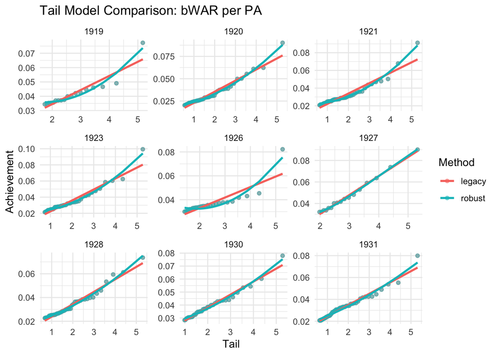

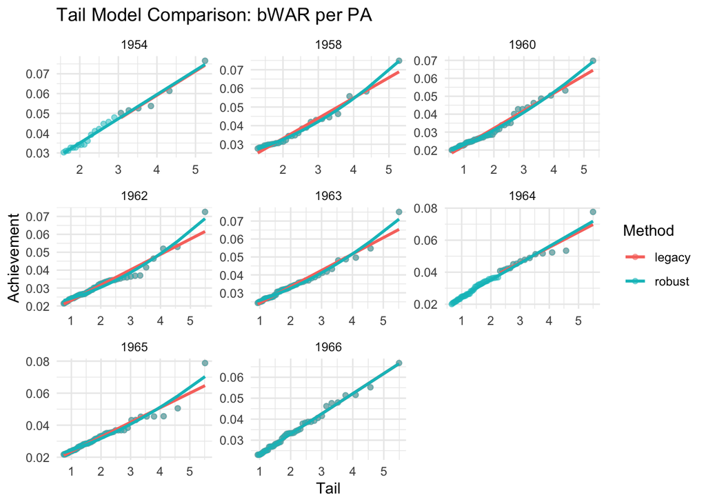

Because our objective is to highlight and preserve the extremeness of historically significant performances, we adopt the legacy fitting approach. Accordingly, version 3.1 implements the legacy method in these analyses.